# Exercise 11.3

Lucia Camenisch

19 novembre 2022

First of all, we upload the necessary packages.

```r
library(data.table)   # data table, fread()
library(fastDummies)  # dummy_cols()
library(caret)        # preProcess()
library(neuralnet)    # making neural networks
library(forecast)     # accuracy()
library(dplyr)        # bind_rows()
library(ggplot2)      # plotting

options(scipen = 999) # disable scientific notation
```

Then, we load our data and keep only the relevant variables for this exercise.

```r
ToyotaCorolla <- fread("ToyotaCorolla.csv") # importing data
# selecting columns cited in exercise
ToyotaCorolla <- ToyotaCorolla[, list(Price, Age_08_04, KM, Fuel_Type, HP, Automatic,
                                      Doors, Quarterly_Tax, Mfr_Guarantee,
                                      Guarantee_Period, Airco, Automatic_airco,
                                      CD_Player, Powered_Windows, Sport_Model, Tow_Bar)]
```

Please refer to exercise 6.4 for the data exploration phase.

We convert `Fuel_Type` to dummies using `dummy_cols` from the `fastDummies` package and normalize our numerical variables using `preProcess` from the `caret` package with the `"range"` method. This method will scale all our variables to the $[0,1]$ interval.

```r
# creating dummies, remove_first_dummy will only create two dummies for petrol and diesel
ToyotaCorolla <- dummy_cols(ToyotaCorolla, select_columns = "Fuel_Type", remove_first_dummy = TRUE)
# taking out fuel_type from the data now that we have the two dummies
ToyotaCorolla <- ToyotaCorolla[, c(1:3, 5:18)]
# normalizing numerical variables
norm.values <- preProcess(ToyotaCorolla[, c(1:4, 6, 7, 9)], method = "range")
ToyotaCorolla <- predict(norm.values, ToyotaCorolla)
```

We partition the data into training and validation sets.

```r
set.seed(111)  # set seed for reproducing the partition

# generating training set index
train.index <- sample(c(1:nrow(ToyotaCorolla)), 0.6*nrow(ToyotaCorolla))
# generating validation set index as the complementary of training set
valid.index <- setdiff(c(1:nrow(ToyotaCorolla)), train.index)

# creating data tables Train and Valid using the indexes
Train <- ToyotaCorolla[train.index, ]
Valid <- ToyotaCorolla[valid.index, ]

# removing indexes as they aren't used anymore
rm(train.index, valid.index)
```

# 1 Fit neural network models to the data.

We fit three neural networks:

1. `NN2` with one hidden layer of two nodes;
2. `NN5` with one hidden layer of five nodes;
3. `NN55` with two hidden layers of five nodes each.

```r
set.seed(111)
# we use neuralnet() from the neuralnet package
NN2 <-neuralnet(Price ~. , data = Train,
                linear.output = FALSE,   # the outputs are run through a transfer/activation function
                hidden = 2)              # 2 hidden nodes in 1 layer
NN2$weights                              # displaying weights
```

```
## [[1]]
## [[1]][[1]]
##              [,1]        [,2]
##  [1,] -0.72703496 -0.06877881
##  [2,] -2.39175928 -2.23187341
##  [3,] -1.23272691 -1.22485260
##  [4,]  0.31312977  1.33799448
##  [5,] -0.12342319  0.39615733
##  [6,]  0.05164504  0.22316507
##  [7,]  0.24394417  1.43241557
##  [8,]  0.13261555  0.02479468
##  [9,]  2.14080380 -0.38213431
## [10,]  0.80653364 -0.51327067
## [11,]  0.31537072  0.28676733
## [12,]  0.13423509 -0.02595315
## [13,]  1.20909828 -0.61104139
## [14,]  0.12147197 -0.03053817
## [15,] -0.01709366 -0.05324549
## [16,] -0.11768957  0.29047916
## [17,]  0.31420289  0.15596224
##
## [[1]][[2]]
##           [,1]
## [1,] -2.406553
## [2,]  1.743574
## [3,]  2.642520
```

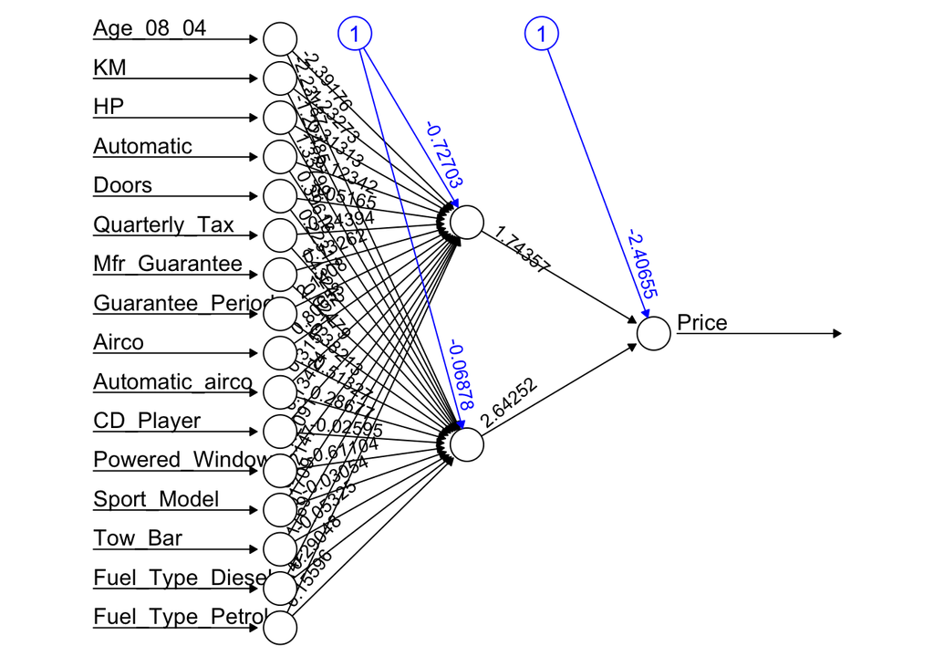

```r
# plotting, rep="best" means that the repetition with the smallest error will be plotted
plot(NN2, rep = "best")
```

```r
# same steps and parameters as before except for hidden
set.seed(111)
NN5 <-  neuralnet(Price ~. , data = Train, linear.output = FALSE, hidden = 5)
NN5$weights
```

```
## [[1]]
## [[1]][[1]]
##              [,1]       [,2]       [,3]        [,4]        [,5]
##  [1,]  0.55641833  0.2384417 -1.6764130   0.6427410 -0.85595550
##  [2,]  0.98307987  1.6617768  3.1185626 -13.8495208 -5.03829032
##  [3,]  0.18052831  2.4715413  1.2493770   1.4857745  0.02194851
##  [4,] -2.18144365  0.7177358 -0.7053907   4.7377165  2.74623176
##  [5,] -1.03126341 -0.5154120  0.8671168   2.0914058  0.95239442
##  [6,]  0.01448989  0.7259811 -0.7758235   0.1577613  1.27149049
##  [7,] -1.15720401 -1.5420483 -0.9957801   1.2655893 -1.57695222
##  [8,] -0.48001546  0.5883245 -0.3057571  -0.1016298  0.36758529
##  [9,] -7.17483368 -0.2041961  3.1463639   1.9945639 -0.50444799
## [10,] -0.14901439 -0.3964094  0.1210310  -0.4990996 -0.33815396
## [11,] -2.44548566  3.5900749  0.3625226   6.5248431  2.59415261
## [12,] -1.32403492  0.7118084  0.2687373  -1.0262273  0.36475058
## [13,]  1.52346958 -1.4029829 -0.3579724   1.1718337 -0.87830798
## [14,]  0.56969102 -0.8265998  0.1902221   0.8637181 -0.09076248
## [15,]  0.09379309 -0.3116737  0.3490184   1.2454196  0.14009765
## [16,] -1.12536019 -2.1478325  1.6943649  -0.6085004  0.70514646
## [17,] -0.85542386 -1.0007494 -0.2539686  -1.2102463 -2.46189006
##
## [[1]][[2]]
##            [,1]
## [1,]  0.3785063
## [2,] -1.0465968
## [3,] -1.0997232
## [4,] -1.3511671
## [5,]  0.6811024
## [6,]  1.1580205
```

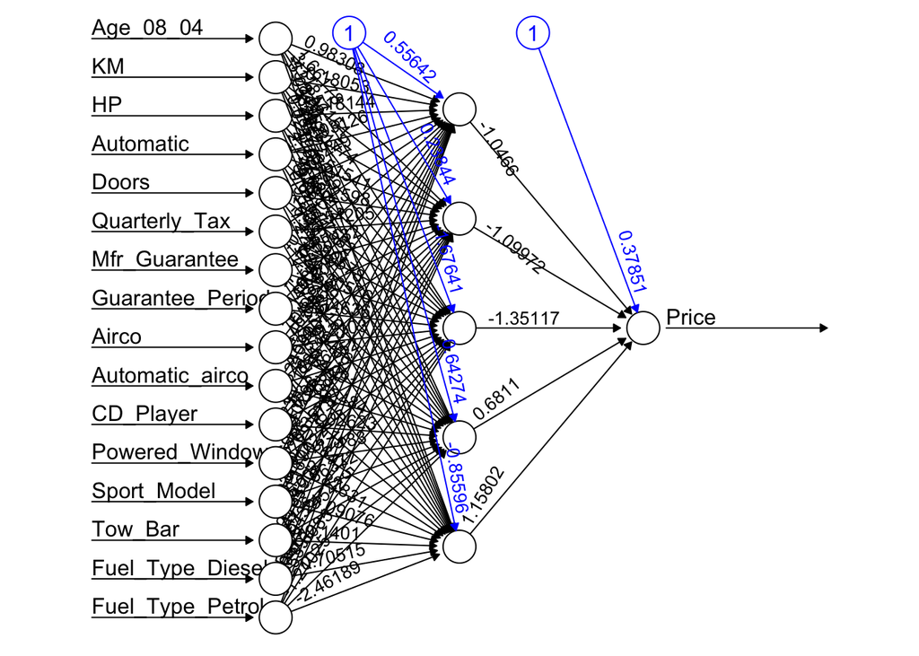

```r
plot(NN5, rep = "best")
```

```r
# same steps and parameters as before except for hidden
set.seed(111)
NN55 <-  neuralnet(Price ~. , data = Train, linear.output = FALSE, hidden = c(5, 5))
NN55$weights
```

```
## [[1]]
## [[1]][[1]]
##             [,1]        [,2]       [,3]        [,4]         [,5]
##  [1,] -0.3069068  0.30522103 -2.3032857   0.1238467  0.301411349
##  [2,] -4.9026334 -2.50442544  3.1128384   4.2207975  2.155161843
##  [3,]  0.6990544 -1.19419280  2.9007839  -8.3928766  0.157189144
##  [4,] -3.2004364  3.79246805 -0.7426374 -13.6395376 -1.023930502
##  [5,]  2.5477804 -0.78185233 -0.5568941  -8.3657647 -0.041838406
##  [6,]  1.3004445  1.34684253 -1.0319868   1.8249130  0.568371305
##  [7,] -1.6388583  1.54618418 -2.5515252   8.5424692 -0.435647975
##  [8,] -0.1586068  0.09490794 -0.2875759   3.8920455  0.005279892
##  [9,]  8.9057907  1.47021760 -4.5691837  26.9026810  2.197481807
## [10,]  1.3203353 -1.34883253 -0.3505510   0.5573718 -0.053837439
## [11,]  7.1595501  0.14780972  0.9155571  -2.5881753  0.549067109
## [12,]  0.5377618  0.24109412 -0.4361897  42.5882778  0.236800439
```

[output cut: 23 more lines]

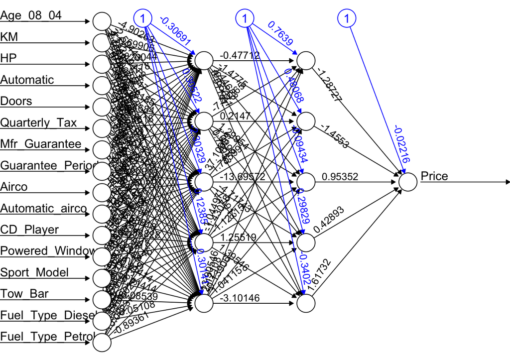

```r
plot(NN55, rep = "best")
```

# 2 Record the RMS error of each neural network for the training data and the validation data.

Now that we have our three neural nets, we will look at the accuracy measures and perform the residual analysis for each of them.

To do so, we must rescale back `Price` so that the values represent euros.

Recall that to scale the variables, we used the `"range"` method, which normalizes as follows:

$$X_{norm} = \dfrac{X-a}{b-a}$$
with $a$ and $b$ the minimal and maximal values taken by the variable. Thus, to scale back, we will compute

$$X = (b-a)X_{norm} + a$$

In our `norm.values` object, we fetch $a$ and $b$ for `Price`.

```r
norm.values$ranges           # displaying all ranges of scaled variables
```

```
##      Price Age_08_04     KM  HP Doors Quarterly_Tax Guarantee_Period
## [1,]  4350         1      1  69     2            19                3
## [2,] 32500        80 243000 192     5           283               36
```

```r
a = norm.values$ranges[1,1]  # fetching a for Price
b = norm.values$ranges[2,1]  # fetching b for Price
```

We construct outcome tables for our `Train` and `Valid` sets for all three neural networks. These tables contain prices, predicted prices and residuals for both sets.

We start with the tables for `NN2`.

```r
# creating TrainOutcomes with Values and PredictedValues which are obtained using the predict()
# function on our neuralnetwork and Train set
TrainOutcomes = data.table(Values = Train$Price, PredictedValues = predict(NN2, Train))
# Renaming the column PredictedValues as for some reason I haven't understood, it appears as
# PredictedValues.V1 when created
colnames(TrainOutcomes)[2] = "PredictedValues"

# scaling back the two columns using the formula stated before
TrainOutcomes = (b-a)*TrainOutcomes + a
# defining the Residuals column
TrainOutcomes = TrainOutcomes[, Residuals := Values - PredictedValues]

# same steps for ValidOutcomes
ValidOutcomes = data.table(Values = Valid$Price, PredictedValues = predict(NN2, Valid))
colnames(ValidOutcomes)[2] = "PredictedValues"

ValidOutcomes = (b-a)*ValidOutcomes + a
ValidOutcomes = ValidOutcomes[, Residuals := Values - PredictedValues]
```

We compute the accuracy measures for both sets and store them.

```r
# we use the accuracy() function from the forecast package
AccNN2Train = accuracy(object = TrainOutcomes$PredictedValues, x = TrainOutcomes$Values)
AccNN2Valid = accuracy(object = ValidOutcomes$PredictedValues, x = ValidOutcomes$Values)
AccNN2Train # displaying accuracy measures for Train
```

```
##                 ME     RMSE      MAE      MPE     MAPE
## Test set -1.968602 1091.009 837.9301 -1.29054 8.420052
```

```r
AccNN2Valid # displaying accuracy measures for Valid
```

```
##                 ME     RMSE      MAE       MPE     MAPE
## Test set -38.50958 1129.469 841.1189 -1.693891 8.488594
```

We store `TrainOutcomes` and `ValidOutcomes` one on top of the other in a table called `Outcomes`, with a categorical variable that indicates to which set and neural network each row belongs.

The outcomes for the other two neural networks will be added to this `Outcomes` table later.

```r
# bind_rows from dplyr package allows to stack the two tables together
# we add a new column called Set which takes the value "TrainNN2" or "ValidNN2"
Outcomes = bind_rows(TrainOutcomes[, Set := "TrainNN2"], ValidOutcomes[, Set := "ValidNN2"])
```

We now create the outcome tables for `NN5`.

```r
# exactly the same method as before
TrainOutcomes = data.table(Values = Train$Price, PredictedValues = predict(NN5, Train))
colnames(TrainOutcomes)[2] = "PredictedValues"

TrainOutcomes = (b-a)*TrainOutcomes + a
TrainOutcomes = TrainOutcomes[, Residuals := Values - PredictedValues]

ValidOutcomes = data.table(Values = Valid$Price, PredictedValues = predict(NN5, Valid))
colnames(ValidOutcomes)[2] = "PredictedValues"

ValidOutcomes = (b-a)*ValidOutcomes + a
ValidOutcomes = ValidOutcomes[, Residuals := Values - PredictedValues]
```

We compute the accuracy measures for both sets and store them.

```r
# exactly the same method as before
AccNN5Train = accuracy(object = TrainOutcomes$PredictedValues, x = TrainOutcomes$Values)
AccNN5Valid = accuracy(object = ValidOutcomes$PredictedValues, x = ValidOutcomes$Values)
AccNN5Train
```

```
##                 ME     RMSE      MAE       MPE     MAPE
## Test set 0.5428682 1004.488 767.7902 -1.089251 7.738289
```

```r
AccNN5Valid
```

```
##                 ME    RMSE      MAE       MPE     MAPE
## Test set -4.524848 1125.49 829.0624 -1.408501 8.311114
```

We add the outcome tables for `NN5` to `Outcomes` by stacking them.

```r
Outcomes = bind_rows(Outcomes, TrainOutcomes[, Set := "TrainNN5"]) # adding TrainOutcomes for NN5
Outcomes = bind_rows(Outcomes, ValidOutcomes[, Set := "ValidNN5"]) # adding ValidOutcomes for NN5
```

```r
# exactly the same method as before
TrainOutcomes = data.table(Values = Train$Price, PredictedValues = predict(NN55, Train))
colnames(TrainOutcomes)[2] = "PredictedValues"

TrainOutcomes = (b-a)*TrainOutcomes + a
TrainOutcomes = TrainOutcomes[, Residuals := Values - PredictedValues]

ValidOutcomes = data.table(Values = Valid$Price, PredictedValues = predict(NN55, Valid))
colnames(ValidOutcomes)[2] = "PredictedValues"

ValidOutcomes = (b-a)*ValidOutcomes + a
ValidOutcomes = ValidOutcomes[, Residuals := Values - PredictedValues]
```

We compute the accuracy measures for both sets and store them.

```r
# exactly the same method as before
AccNN55Train = accuracy(object = TrainOutcomes$PredictedValues, x = TrainOutcomes$Values)
AccNN55Valid = accuracy(object = ValidOutcomes$PredictedValues, x = ValidOutcomes$Values)
AccNN55Train
```

```
##                ME     RMSE      MAE       MPE     MAPE
## Test set 1.757064 950.0541 733.9905 -1.005969 7.448774
```

```r
AccNN55Valid
```

```
##                 ME     RMSE      MAE       MPE     MAPE
## Test set -72.51188 1171.776 836.1647 -1.728722 8.285306
```

We add the outcome tables for `NN55` to `Outcomes` by stacking them.

```r
Outcomes = bind_rows(Outcomes, TrainOutcomes[, Set := "TrainNN55"]) # adding TrainOutcomes for NN55
Outcomes = bind_rows(Outcomes, ValidOutcomes[, Set := "ValidNN55"]) # adding ValidOutcomes for NN55
```

We can now display:

- Boxplot of Residuals
- Histogram of Residuals
- Residuals versus Predicted Values Scatterplot
- Normal QQ Plot of Residuals

for each of our three neural networks and training/validation sets (six plots in total).

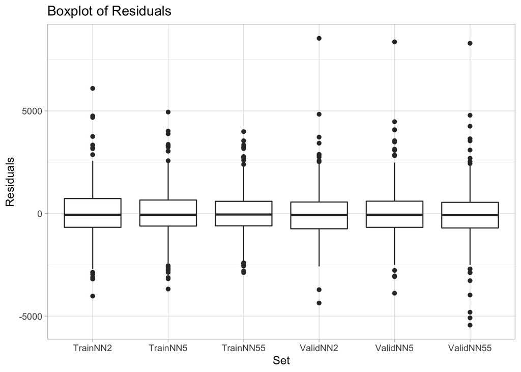

```r
ggplot(data = Outcomes, aes(x = Set, y = Residuals)) +   # plotting residuals
  geom_boxplot() +                                       # making boxplot
  theme_light() +                                        # changing aesthetic theme
  labs(y = "Residuals", title = "Boxplot of Residuals")  # writing labels
```

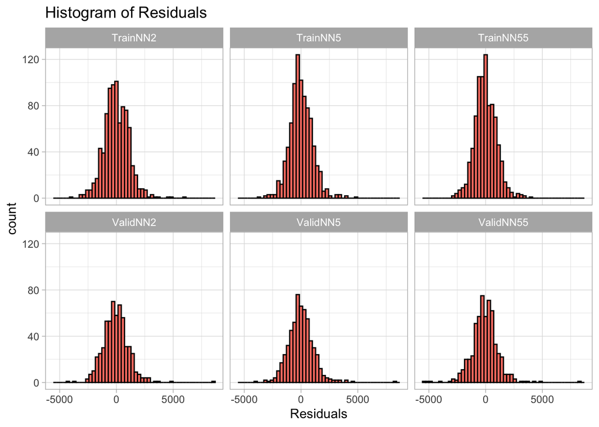

```r
# same as previous plot but using geom_histogram to draw the histogram
# facet_wrap in all the following plots allows to draw one plot for Train and one for Valid
ggplot(data = Outcomes, aes(Residuals)) +
  facet_wrap(~Set) +
  geom_histogram(color = "black", fill = "#FA8072", bins = 50) +
  theme_light() +
  labs(title = "Histogram of Residuals")
```

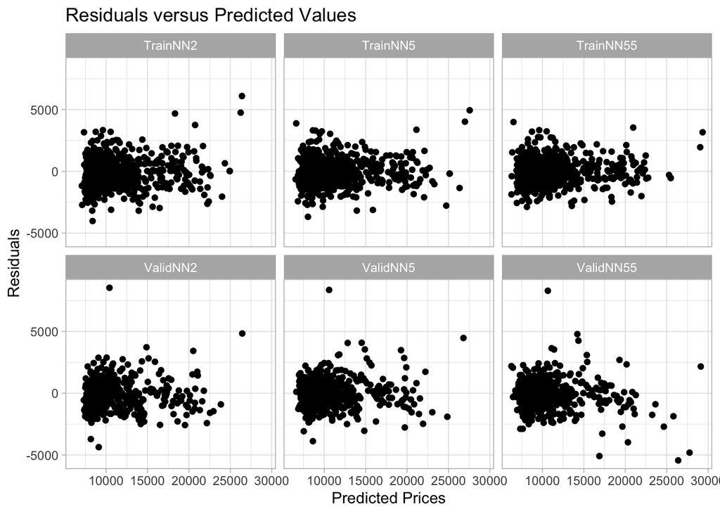

```r
# same as previous plot but using geom_point to draw points on the plot
ggplot(data = Outcomes, aes(x = PredictedValues, y = Residuals)) +
  facet_wrap(~Set) +
  geom_point() +
  theme_light() +
  labs(x = "Predicted Prices", y = "Residuals", title = "Residuals versus Predicted Values")
```

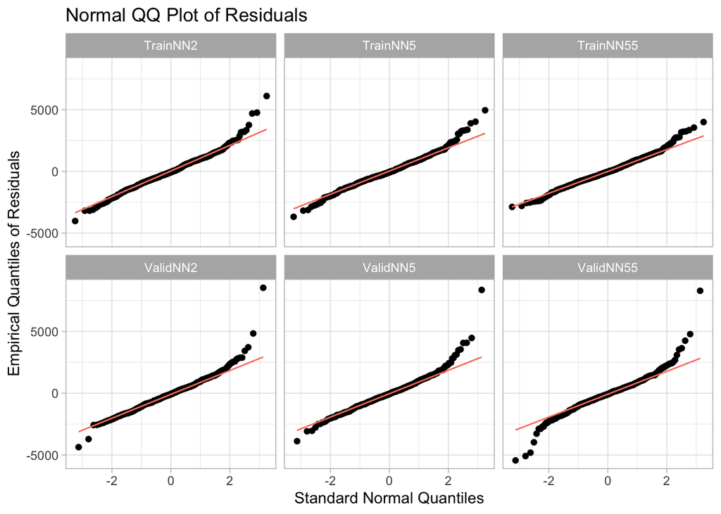

```r
# same as previous plot but using geom_qq to draw residuals points on the plot and
# geom_qq_line to draw the straight line
ggplot(data = Outcomes, aes(sample = Residuals)) +
  facet_wrap(~Set) +
  geom_qq() +
  geom_qq_line(color = "#FA8072") +
  theme_light() +
  labs(x = "Standard Normal Quantiles", y = "Empirical Quantiles of Residuals",
       title = "Normal QQ Plot of Residuals")
```

All four kinds of plots indicate the general tendency of our neural networks to overfit the training data as the complexity of the neural network increases (for `Train`: the boxplots decrease in height, the residuals’ histograms get higher around zero, outliers become more squished in the scatterplots and the residuals become more normally distributed in the QQ plots).

However, for our validation data, the scenario is very different! `NN55` clearly has the worst performances out of the three neural nets, with boxplot and scatterplot showing more spread out or extreme outliers and a stronger departure from normality in the QQ plot. The residuals histogram is similar to the one for `NN2`, the differences in extreme outliers being too small on the overall count scale to be clearly visible.

For the validation data, `NN5` seems to be the better model. Except for the extremely positive residual visible in all `Valid` boxplots, the rest of residuals are more gathered towards zero than in `NN2`.This histogram peaks higher at zero as well.

We will now examine the accuracy measures.

## 2.1 What happens to the RMS error for the training data as the number of layers and nodes increases?

Let us display the accuracy measures for `Train`. For a recall on the meaning of those measures, please consult exercise 6.4.

```r
AccNN2Train
```

```
##                 ME     RMSE      MAE      MPE     MAPE
## Test set -1.968602 1091.009 837.9301 -1.29054 8.420052
```

```r
AccNN5Train
```

```
##                 ME     RMSE      MAE       MPE     MAPE
## Test set 0.5428682 1004.488 767.7902 -1.089251 7.738289
```

```r
AccNN55Train
```

```
##                ME     RMSE      MAE       MPE     MAPE
## Test set 1.757064 950.0541 733.9905 -1.005969 7.448774
```

## 2.2 What happens to the RMS error for the validation data?

Let us display the accuracy measures for `Valid`.

```r
AccNN2Valid
```

```
##                 ME     RMSE      MAE       MPE     MAPE
## Test set -38.50958 1129.469 841.1189 -1.693891 8.488594
```

```r
AccNN5Valid
```

```
##                 ME    RMSE      MAE       MPE     MAPE
## Test set -4.524848 1125.49 829.0624 -1.408501 8.311114
```

```r
AccNN55Valid
```

```
##                 ME     RMSE      MAE       MPE     MAPE
## Test set -72.51188 1171.776 836.1647 -1.728722 8.285306
```

We can see that `NN55` has the highest RMSE. This seems logical, as it had the biggest and most spread out residuals. It also has the biggest ME in absolute value. `NN5` looks like the best model here as well, as it has the smallest ME, RMSE, MAE and MPE in absolute value.

## 2.3 Comment on the appropriate number of layers and nodes for this application.

The evolution of the RMSE for new or unseen data usually follows a positive parabolic shape with respect to the model complexity: It starts out high when the model is very simple, and decreases for a bit, until the model becomes too complex because it starts modeling the noise of the training data (overfitting), at which point the RMSE starts to increase again. To have a low RMSE, we need to find a compromise between the complexity of the model and the danger of overfitting training data.

In other words, what may be happening here is that `NN2` is a very simplistic model, `NN55` overfits `Train` and `NN5` is a good compromise between the two extremes, resulting as the best version of our three neural networks to predict new data.